# In-class Excercise 1

Before we get started, it is important for us to ensure that the required R packages have been installed. If yes, we will load the R pacakges. If they have yet to be installed, we will install the R packages and load them onto R environment.

```r
packages = c('tidyverse','ggdist','gghalves')
for(p in packages){
if(!require(p, character.only = T)){
install.packages(p)
}
library(p, character.only = T)
}
```

The code chunk below imports exam_data.csv into R environment using read_csv() function of readr package.

```r
exam_data <- read_csv("./data/Exam_data.csv")
```

## ggplot2

- Data: The dataset being plotted.
- Aesthetics: take attributes of the data and use them to influence visual characteristics, such as position, colours, size, shape, or transparency.
- Geometrics: The visual elements used for our data, such as point, bar or line.

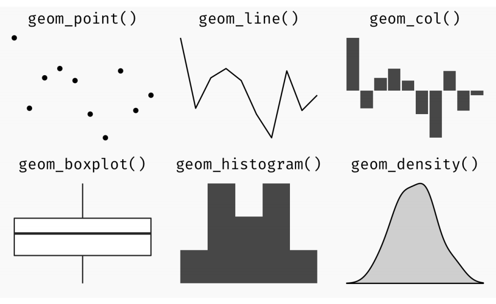

- Facets: split the data into subsets to create multiple variations of the same graph (paneling, multiple plots).
- Statistics: statiscal transformations that summarise data (e.g. mean, confidence intervals). Coordinate systems define the plane on which data are mapped on the graphic.
- Themes: modify all non-data components of a plot, such as main title, sub-title, y-aixs title, or legend background.

### Aethetics

The code chunk on the right add the aesthetic element into the plot. Notice that ggplot includes the x-axis and the axis’s label.

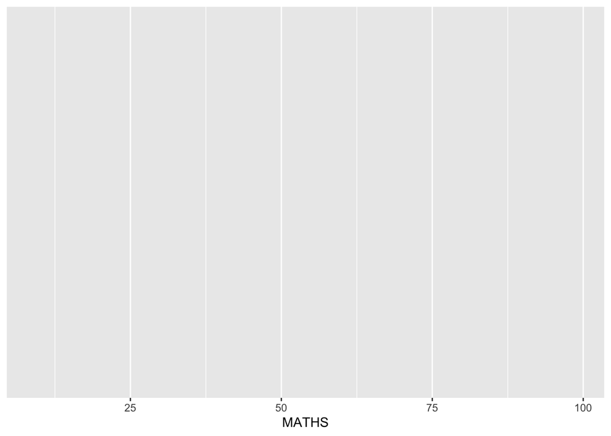

```r
ggplot(data=exam_data, aes(x= MATHS))
```

### Geometric Objects: geom_bar

The code chunk below plots a bar chart.

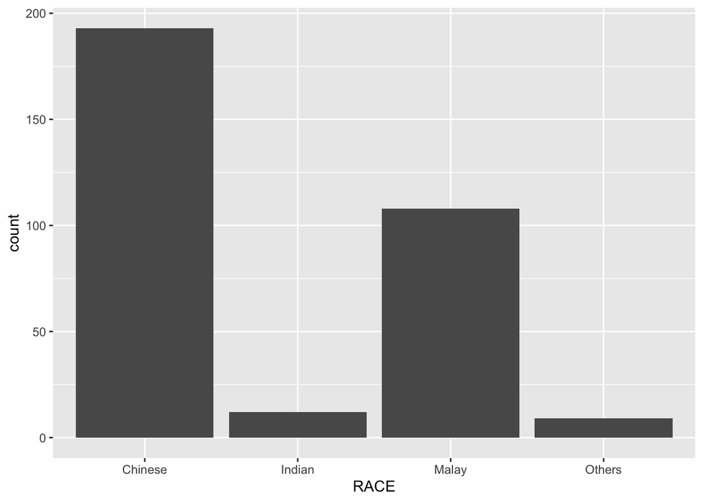

```r
ggplot(data=exam_data,
aes(x=RACE)) +
geom_bar()
```

### Geometric Objects: geom_dotplot

In a dot plot, the width of a dot corresponds to the bin width (or maximum width, depending on the binning algorithm), and dots are stacked, with each dot representing one observation.

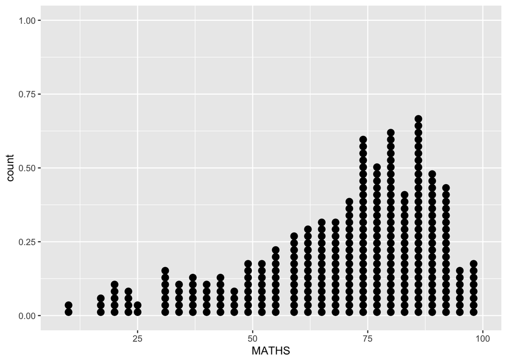

```r
ggplot(data=exam_data,
  aes(x = MATHS)) +
  geom_dotplot(dotsize = 0.5)
```

The code chunk below performs the following two steps:

- scale_y_continuous() is used to turn off the y-axis, and
- binwidth argument is used to change the binwidth to 2.5.

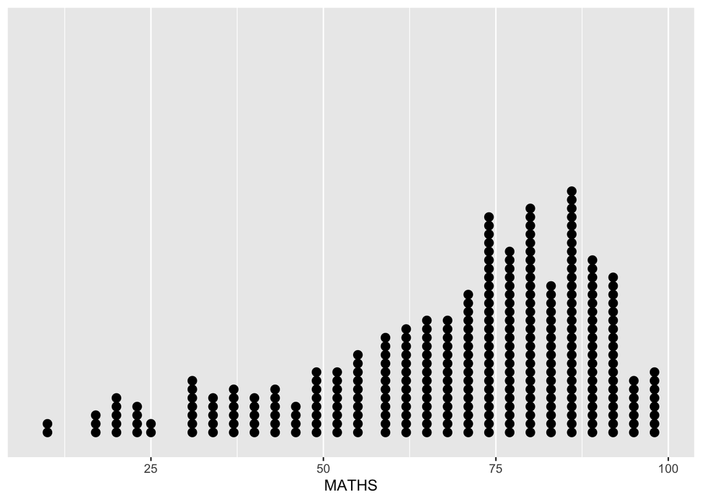

```r
ggplot(data=exam_data, aes(x = MATHS)) +
  geom_dotplot(binwidth=2.5, dotsize = 0.5) +
  scale_y_continuous(NULL, breaks = NULL)
```

### Geometric Objects: geom_histogram

In the code chunk below, geom_histogram() is used to a simple histogram by using values in MATHS field of exam_data.

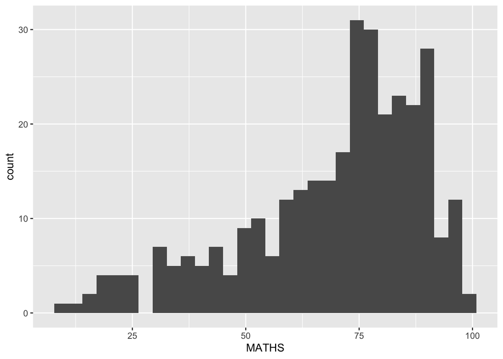

```r
ggplot(data=exam_data,
aes(x = MATHS)) +
geom_histogram()
```

#### Modifying a geometric object by changing geom()

In the code chunk below,

- bins argument is used to change the number of bins to 20,
- fill argument is used to shade the histogram with light blue color, and color argument is used to change the outline colour of the bars in black

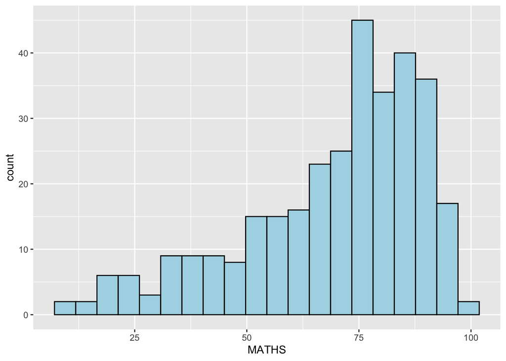

```r
ggplot(data=exam_data,
       aes(x= MATHS)) +
  geom_histogram(bins=20,
                 color="black",
                 fill="light blue")
```

#### Modifying a geometric object by changing aes()

- The code chunk below changes the interior colour of the histogram (i.e. fill) by using sub- group of aesthetic().
- Note that this approach can be used to **colour, fill and alpha** of the geometric.

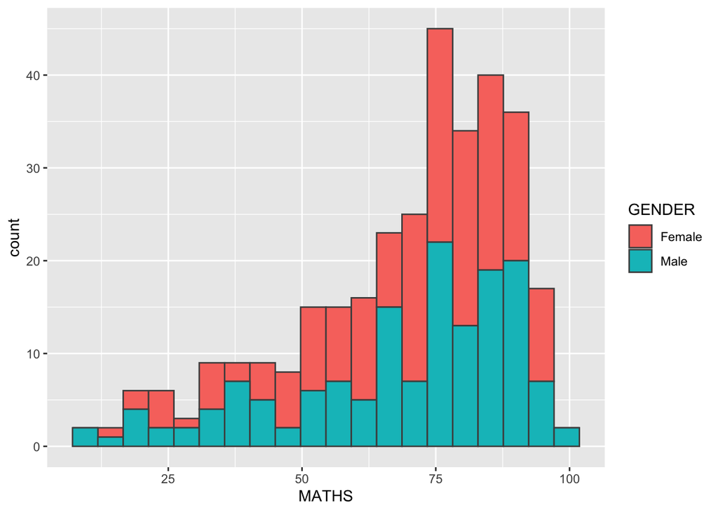

```r
ggplot(data=exam_data,
aes(x= MATHS,
fill = GENDER)) +
geom_histogram(bins=20,
color="grey30")
```

### Geometric Objects: geom-density

geom-density() computes and plots kernel density estimate, which is a smoothed version of the histogram.

It is a useful alternative to the histogram for continuous data that comes from an underlying smooth distribution.

The code below plots the distribution of Maths scores in a kernel density estimate plot.

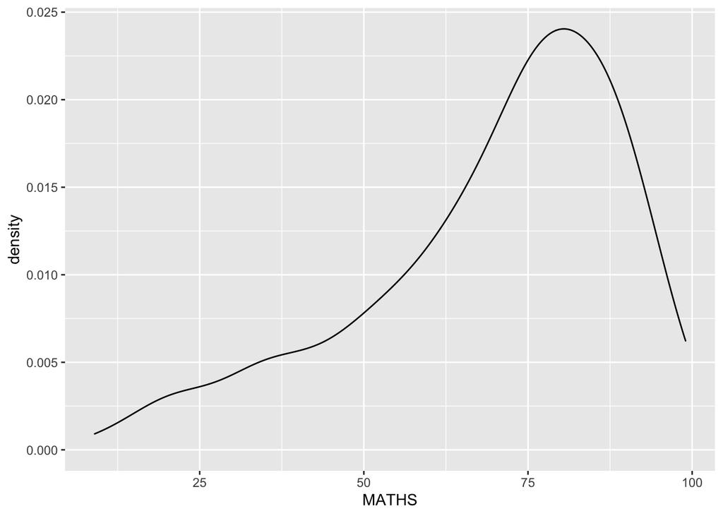

```r
ggplot(data=exam_data,
       aes(x = MATHS)) +
  geom_density()
```

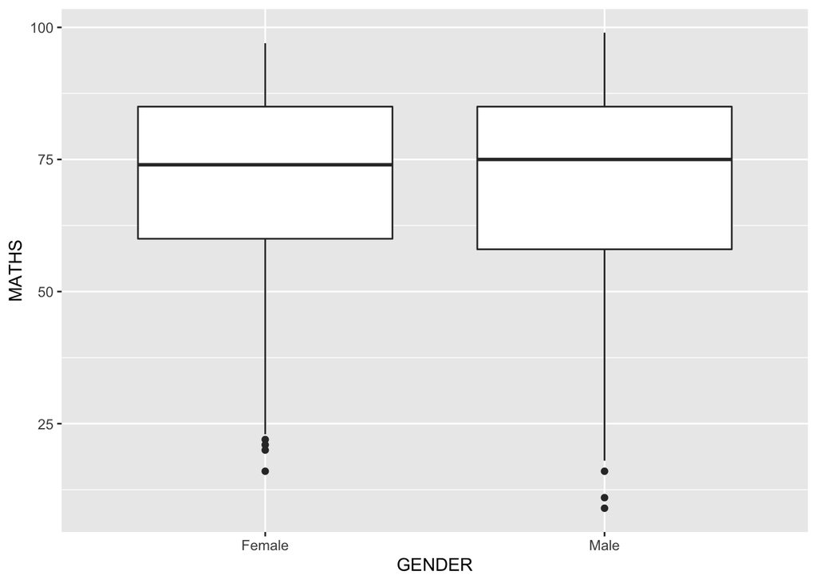

```r
ggplot(data=exam_data,
aes(y = MATHS,
x= GENDER)) +
geom_boxplot()
```

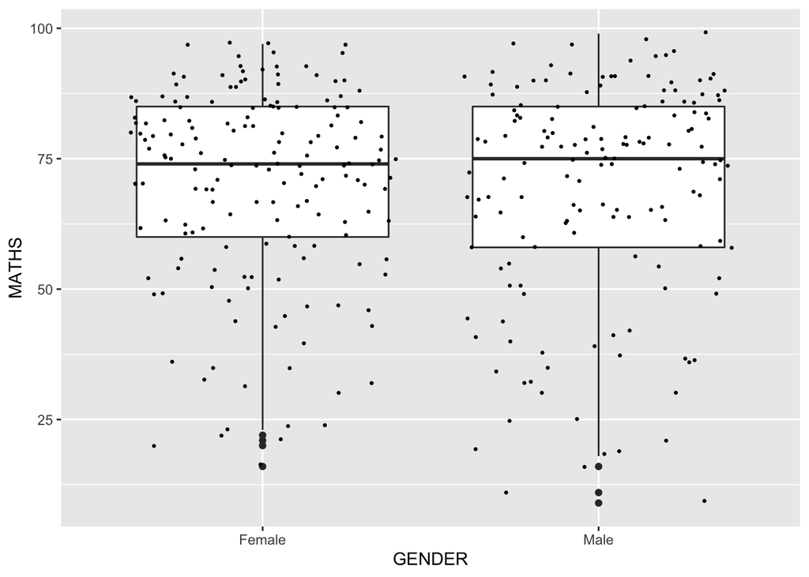

```r
ggplot(data=exam_data,
aes(y = MATHS,
x= GENDER)) +
geom_boxplot() +
geom_point(position="jitter",
size = 0.5)
```

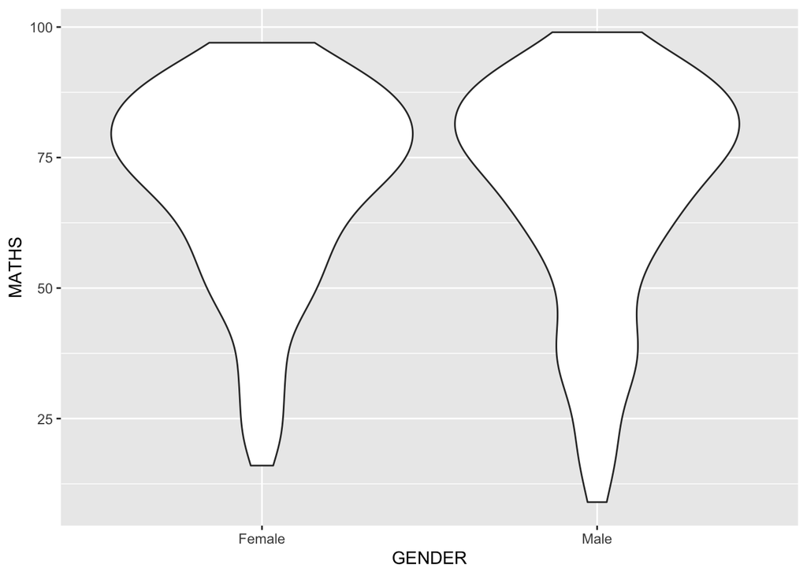

```r
ggplot(data=exam_data,
aes(y = MATHS,
x= GENDER)) +
geom_violin()
```

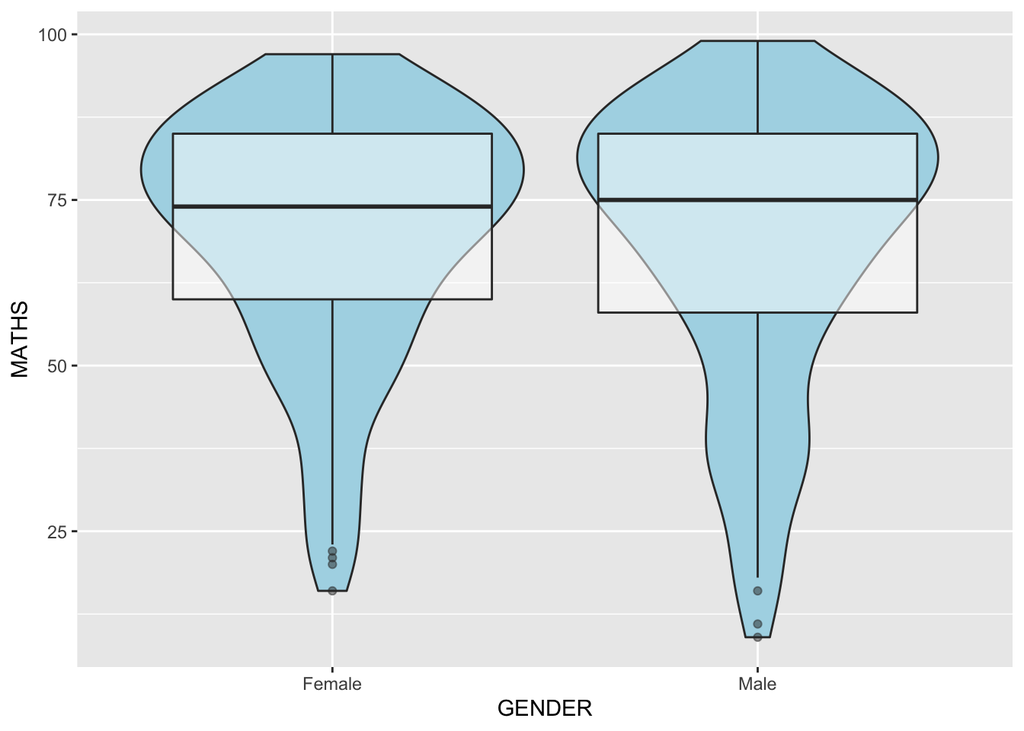

```r
ggplot(data=exam_data,
aes(y = MATHS,
x= GENDER)) +
geom_violin(fill="light blue") +
geom_boxplot(alpha=0.5)
```

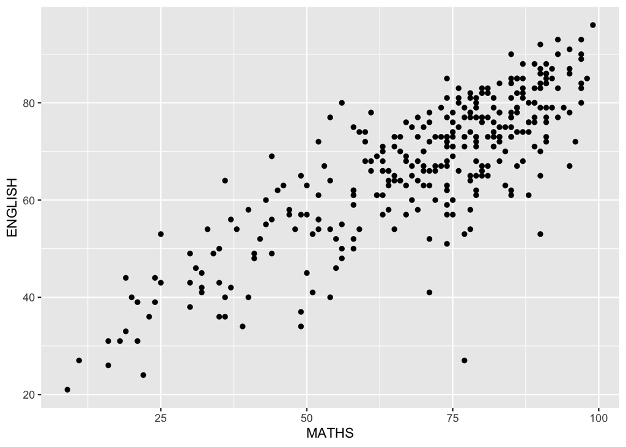

```r
ggplot(data=exam_data,
aes(x= MATHS,
y=ENGLISH)) +
geom_point()
```